# **Упражнение 1.1**

Посмотреть с помощью chap01.ipynb примеры и пояснения.

# **Упражнение 1.2**

Скачайте с сайта https://freesound.org/ образец звука, включающий музыку, речь или иные звуки, имеющие четко выраженную высоту. Выделите примерно полусекундный сегмент, в котором высота постоянна. Вычислите и распечатайте спектр выбранного сегмента. Как связанны тембр звука и гармоническая структура, видимая в спепктре?

Используйте high_pass, low_pass и band_stop для фильтрации тех или иных гармоник. Затем преобразуйте спектры обратно в сигнал и прослушайте его. Как звук соотносится с изменениями, сделанными в спектре?

Ипморт библиотек и файлов:

```python
import os
if not os.path.exists('thinkdsp.py'):
    !wget https://github.com/AllenDowney/ThinkDSP/raw/master/code/thinkdsp.py

if not os.path.exists('92002__jcveliz__violin-origional.wav'):
    !wget https://github.com/TrombBone/TelecomLabs/raw/main/92002__jcveliz__violin-origional.wav
```

[output not shown]

Создадим объект `wave` из скачанного звука, создадим сам звук для прослушивания:

```python
from thinkdsp import read_wave

wave = read_wave('92002__jcveliz__violin-origional.wav')
wave.normalize()
wave.make_audio()
```

[interactive chart not shown]

Построим график сегмента нашего звука:

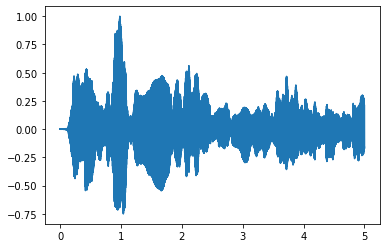

```python
wave.plot()
```

Выделим полусекундный сегмент, где высота постоянна и послушаем его:

[interactive chart not shown]

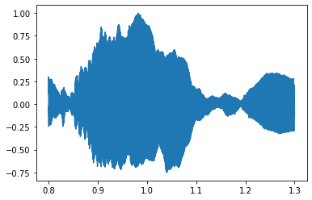

```python
segment = wave.segment(0.8,0.5)
segment.plot()
segment.make_audio()
```

Вычислим и выведем спектр выделенного сегмента:

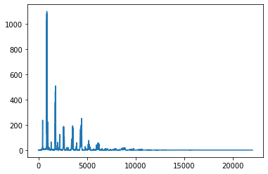

```python
spectrum = segment.make_spectrum()
spectrum.plot()
```

Исходя из спектра, можно сделать вывод, что звук локализован примерно в первых 7 кГц. Выведем спектр этого диапазона:

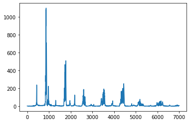

```python
spectrum.plot(high = 7000)
```

Приблизим диаграмму до 2 кГц:

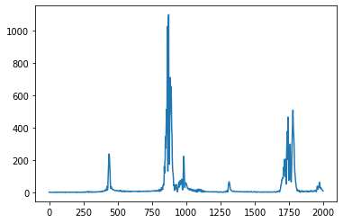

```python
spectrum.plot(2000)
```

Выделим доминирующую частоту:

```python
spectrum.peaks()[:5]
```

```
[(1101.6542667797148, 872.0),
 (1083.744407422266, 868.0),
 (1028.4605029668771, 862.0),
 (917.0417079501855, 864.0),
 (898.752433214703, 870.0)]
```

Видно, что доминирующая частота - 872 Гц (первая в списке).

Воспользуемся `low_pass`, тем самым отфильтруем всё, что выше 2 кГц:

```python
spectrum.low_pass(2000)
filtered = spectrum.make_wave()
```

Сравним исходный звук (первый) и получившийся отфильтрованный (второй):

```python
segment.make_audio()
```

[interactive chart not shown]

```python
filtered.make_audio()
```

[interactive chart not shown]

Видно, что звук стал более полым и глухим, как будто бы "в банке". Это следствие того, что с обрезанием частот изменилась форма сигнала и его тембр.

Теперь воспользуемся `high_pass` и `band_stop` для исходного выделенного сегмента. Посмотрим на получившуюся диаграмму и послушаем, какой звук получился после одновременной фильтрации с помощью фильтра высоких частот (первый метод) и полосно-заграждающего фильтра (второй метод).

[interactive chart not shown]

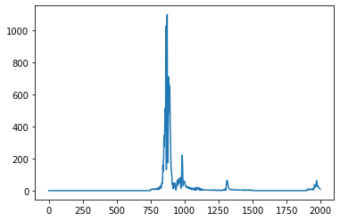

```python
edited = segment.make_spectrum()
edited.high_pass(750)
edited.band_stop(1500,1900)
edited.plot(2000)
edited.make_wave().make_audio()
```

Слышно (и видно), что звук стал немного более звонким и "тонким", как будто бы скрипка стала чуть более электронной, нежели настоящая. Это логично, так как мы срезали большую часть частот, кроме основной, тем самым лишив звука того самого "объёма".

# **Упражнение 1.3**

Создайте сложный сигнал из объектов SinSignal и CosSignal, суммируя их. Обработайте сигнал для получения wave и прослушайте его. Вычислите Spectrum и распечатайте. Что произойдет при добавлении частот, не кратных основным?

Соберём, например, развернутый аккорд До-мажор (C-dur) первой октавы (до-ми-соль-до), но будем использовать как косинус, так и синус. Послушаем и посмотрим, что получилось:

[interactive chart not shown]

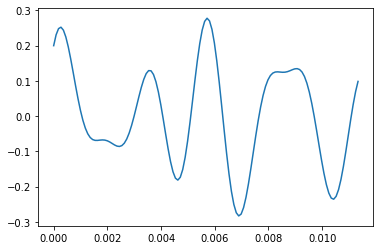

```python
from thinkdsp import SinSignal, CosSignal

sin_C4 = SinSignal(freq=261.63, amp=0.1)
cos_E4 = CosSignal(freq=329.93, amp=0.1)
sin_G4 = SinSignal(freq=392, amp=0.1)
cos_C5 = CosSignal(freq=523.25, amp=0.1)

my_signal = sin_C4 + cos_E4 + sin_G4 + cos_C5
my_signal_wave = my_signal.make_wave(duration=1)
my_signal.plot()
my_signal_wave.make_audio()
```

Вычислим и распечатаем *Spectrum*:

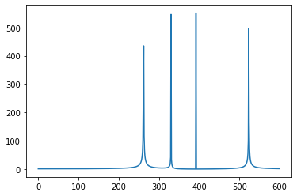

```python
spectrum = my_signal_wave.make_spectrum()
spectrum.plot(high = 600)
```

Попробуем добавить в аккорд ноту, не входящую в него, которую можно считать некратной остальным частотам аккорда. Посмотрим и послушаем, что получилось:

[interactive chart not shown]

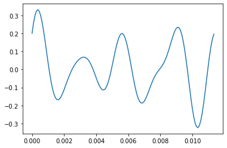

```python
sin_B_bemol = SinSignal(freq=466.16,amp=0.1)
newSignal = my_signal + sin_B_bemol
newSignal_wave = newSignal.make_wave(duration=1)
newSignal.plot()
newSignal_wave.make_audio()
```

Получился гармонический аккорд, так как мы добавили седьмую пониженную ступень в тональности до-мажор (си-бемоль = ля-диез, но в тональности называется именно си-бемоль).

Посмотрим его *Spectrum*:

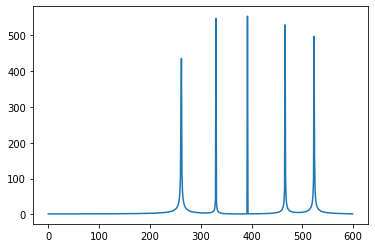

```python
spectrum = newSignal_wave.make_spectrum()
spectrum.plot(high = 600)
```

# **Упражнение 1.4**

Напишите функцию `stretch`, берущую wave и коэффициент изменения. Она должна ускорять или замедлять сигнал изменением `ts` и `framerate`. Подсказка: должно получиться всего 2 строки кода.

Ниже представлена получившаяся функция:

```python
def stretch(wave, factor):
  wave.ts *= factor
  wave.framerate /= factor
```

[interactive chart not shown]

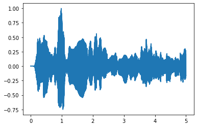

```python
wave = read_wave('92002__jcveliz__violin-origional.wav')
wave.plot()
wave.make_audio()
```

Теперь ускорим наш звук в 2 раза:

[interactive chart not shown]

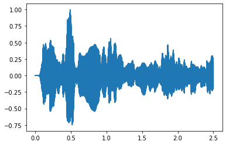

```python
stretch(wave, 0.5)
wave.plot()
wave.make_audio()
```

Теперь наоборот, замедлим в 2 раза:

[interactive chart not shown]

[figure not shown]

```python
stretch(wave, 2)
wave.plot()
wave.make_audio()
```